# Problem Set 7

MGSC 310, Fall 2019, Professor Hersh (BEST PROFESSOR EVER!!!)

Geoffrey Hughes

10/17/2019

## Question 1) What Predicts Bike Share Usage?

1. Read in the Bike Sharing Dataset file (day.csv) into Bike_DF

```r
library('tidyverse')
```

```r
library('coefplot')
library('glmnet')
library('glmnetUtils')
library('leaps')
set.seed(1861)


Bike_DF <- read.csv("/Users/geoffreyhughes/Documents/MGSC_310/MGSC310/Datasets/Bike-Sharing-Dataset/day.csv")
```

2. Clean and factor the data

```r
Bike_DF$weekday <- as.factor(Bike_DF$weekday)
levels(Bike_DF$weekday) <- c("Sunday", "Monday", "Tuesday", "Wednesday", "Thursday", "Friday", "Saturday")

Bike_DF$season <- as.factor(Bike_DF$season)
levels(Bike_DF$season) <- c("Winter", "Spring", "Summer", "Fall")

Bike_DF$mnth <- as.factor(Bike_DF$mnth)
levels(Bike_DF$mnth) <- c("January", "February", "March", "April", "May", "June", "July", "August", "September", "October", "November", "December")

Bike_DF$weathersit <- as.factor(Bike_DF$weathersit)
levels(Bike_DF$weathersit) <- c("Clear", "Light", "Medium", "Heavy")
```

3. Ensure factors are correctly applied

```r
sapply(Bike_DF, is.factor)
```

```
##    instant     dteday     season         yr       mnth    holiday
##      FALSE       TRUE       TRUE      FALSE       TRUE      FALSE
##    weekday workingday weathersit       temp      atemp        hum
##       TRUE      FALSE       TRUE      FALSE      FALSE      FALSE
##  windspeed     casual registered        cnt
##      FALSE      FALSE      FALSE      FALSE
```

4. Create any variables

```r
Bike_DF <- Bike_DF %>% mutate(fahrenheit = (9/5) * temp + 32)
```

5. Train & Test Split of dataset

```r
train_idx <- sample(1:nrow(Bike_DF), size = floor(0.70*nrow(Bike_DF)))
bike_train <- Bike_DF %>% slice(train_idx)
bike_test <- Bike_DF %>% slice(-train_idx)
```

6. Forwards Stepwise Linear Model

```r
fwd_fit <- regsubsets(cnt ~ season + holiday + mnth + workingday + weathersit + temp + hum + windspeed,
                      data = bike_train,
                      nvmax = 4,
                      method = "forward")
```

```
## Reordering variables and trying again:
```

```r
summary(fwd_fit)
```

```
## Subset selection object
## Call: regsubsets.formula(cnt ~ season + holiday + mnth + workingday +
##     weathersit + temp + hum + windspeed, data = bike_train, nvmax = 4,
##     method = "forward")
## 22 Variables  (and intercept)
##                  Forced in Forced out
## seasonSpring         FALSE      FALSE
## seasonSummer         FALSE      FALSE
## seasonFall           FALSE      FALSE
## holiday              FALSE      FALSE
## mnthFebruary         FALSE      FALSE
## mnthMarch            FALSE      FALSE
## mnthApril            FALSE      FALSE
## mnthMay              FALSE      FALSE
## mnthJune             FALSE      FALSE
## mnthJuly             FALSE      FALSE
## mnthAugust           FALSE      FALSE
## mnthSeptember        FALSE      FALSE
## mnthOctober          FALSE      FALSE
## mnthNovember         FALSE      FALSE
## mnthDecember         FALSE      FALSE
## workingday           FALSE      FALSE
## weathersitLight      FALSE      FALSE
## weathersitMedium     FALSE      FALSE
## temp                 FALSE      FALSE
## hum                  FALSE      FALSE
## windspeed            FALSE      FALSE
## weathersitHeavy      FALSE      FALSE
## 1 subsets of each size up to 5
## Selection Algorithm: forward
##          seasonSpring seasonSummer seasonFall holiday mnthFebruary
## 1  ( 1 ) " "          " "          " "        " "     " "
## 2  ( 1 ) " "          " "          " "        " "     " "
## 3  ( 1 ) " "          " "          "*"        " "     " "
## 4  ( 1 ) " "          " "          "*"        " "     " "
## 5  ( 1 ) " "          " "          "*"        " "     " "
##          mnthMarch mnthApril mnthMay mnthJune mnthJuly mnthAugust
## 1  ( 1 ) " "       " "       " "     " "      " "      " "
## 2  ( 1 ) " "       " "       " "     " "      " "      " "
## 3  ( 1 ) " "       " "       " "     " "      " "      " "
## 4  ( 1 ) " "       " "       " "     " "      " "      " "
## 5  ( 1 ) " "       " "       " "     " "      " "      " "
##          mnthSeptember mnthOctober mnthNovember mnthDecember workingday
## 1  ( 1 ) " "           " "         " "          " "          " "
## 2  ( 1 ) " "           " "         " "          " "          " "
## 3  ( 1 ) " "           " "         " "          " "          " "
## 4  ( 1 ) " "           " "         " "          " "          " "
## 5  ( 1 ) "*"           " "         " "          " "          " "
##          weathersitLight weathersitMedium weathersitHeavy temp hum
## 1  ( 1 ) " "             " "              " "             "*"  " "
## 2  ( 1 ) " "             "*"              " "             "*"  " "
## 3  ( 1 ) " "             "*"              " "             "*"  " "
## 4  ( 1 ) " "             "*"              " "             "*"  "*"
## 5  ( 1 ) " "             "*"              " "             "*"  "*"
##          windspeed
## 1  ( 1 ) " "
## 2  ( 1 ) " "
## 3  ( 1 ) " "
## 4  ( 1 ) " "
## 5  ( 1 ) " "
```

```r
bck_fit <- regsubsets(cnt ~ season + holiday + mnth + workingday + weathersit + temp + hum + windspeed,
                       data = bike_train,
                       nvmax = 4,
                       method = "backward")
```

```
## Reordering variables and trying again:
```

```r
summary(bck_fit)
```

```
## Subset selection object
## Call: regsubsets.formula(cnt ~ season + holiday + mnth + workingday +
##     weathersit + temp + hum + windspeed, data = bike_train, nvmax = 4,
##     method = "backward")
## 22 Variables  (and intercept)
##                  Forced in Forced out
## seasonSpring         FALSE      FALSE
## seasonSummer         FALSE      FALSE
## seasonFall           FALSE      FALSE
## holiday              FALSE      FALSE
## mnthFebruary         FALSE      FALSE
## mnthMarch            FALSE      FALSE
## mnthApril            FALSE      FALSE
## mnthMay              FALSE      FALSE
## mnthJune             FALSE      FALSE
## mnthJuly             FALSE      FALSE
## mnthAugust           FALSE      FALSE
## mnthSeptember        FALSE      FALSE
## mnthOctober          FALSE      FALSE
## mnthNovember         FALSE      FALSE
## mnthDecember         FALSE      FALSE
## workingday           FALSE      FALSE
## weathersitLight      FALSE      FALSE
## weathersitMedium     FALSE      FALSE
## temp                 FALSE      FALSE
## hum                  FALSE      FALSE
## windspeed            FALSE      FALSE
## weathersitHeavy      FALSE      FALSE
## 1 subsets of each size up to 5
## Selection Algorithm: backward
##          seasonSpring seasonSummer seasonFall holiday mnthFebruary
## 1  ( 1 ) " "          " "          " "        " "     " "
## 2  ( 1 ) " "          " "          " "        " "     " "
## 3  ( 1 ) " "          " "          "*"        " "     " "
## 4  ( 1 ) " "          " "          "*"        " "     " "
## 5  ( 1 ) " "          " "          "*"        " "     " "
##          mnthMarch mnthApril mnthMay mnthJune mnthJuly mnthAugust
## 1  ( 1 ) " "       " "       " "     " "      " "      " "
## 2  ( 1 ) " "       " "       " "     " "      " "      " "
## 3  ( 1 ) " "       " "       " "     " "      " "      " "
## 4  ( 1 ) " "       " "       " "     " "      " "      " "
## 5  ( 1 ) " "       " "       " "     " "      " "      " "
##          mnthSeptember mnthOctober mnthNovember mnthDecember workingday
## 1  ( 1 ) " "           " "         " "          " "          " "
## 2  ( 1 ) " "           " "         " "          " "          " "
## 3  ( 1 ) " "           " "         " "          " "          " "
## 4  ( 1 ) " "           " "         " "          " "          " "
## 5  ( 1 ) "*"           " "         " "          " "          " "
##          weathersitLight weathersitMedium weathersitHeavy temp hum
## 1  ( 1 ) " "             " "              " "             "*"  " "
## 2  ( 1 ) " "             "*"              " "             "*"  " "
## 3  ( 1 ) " "             "*"              " "             "*"  " "
## 4  ( 1 ) " "             "*"              " "             "*"  "*"
## 5  ( 1 ) " "             "*"              " "             "*"  "*"
##          windspeed
## 1  ( 1 ) " "
## 2  ( 1 ) " "
## 3  ( 1 ) " "
## 4  ( 1 ) " "
## 5  ( 1 ) " "
```

```r
ridge_mod <- cv.glmnet(cnt ~ .,
                       data = bike_train,
                       alpha = 0)

coef(ridge_mod)
```

```
## 770 x 1 sparse Matrix of class "dgCMatrix"
##                              1
## (Intercept)      -3.306589e+03
## instant           3.796743e-01
## dteday2011-01-01 -2.188737e+02
## dteday2011-01-02 -2.323449e+02
## dteday2011-01-03 -1.832695e+02
## dteday2011-01-04  .
## dteday2011-01-05 -1.690196e+02
## dteday2011-01-06 -1.702807e+02
## dteday2011-01-07 -1.640431e+02
## dteday2011-01-08  .
## dteday2011-01-09 -2.153870e+02
## dteday2011-01-10 -1.812788e+02
## dteday2011-01-11 -1.810954e+02
## dteday2011-01-12  .
## dteday2011-01-13 -1.750295e+02
## dteday2011-01-14 -1.787086e+02
## dteday2011-01-15 -1.887302e+02
## dteday2011-01-16 -2.006359e+02
## dteday2011-01-17  .
## dteday2011-01-18 -2.307924e+02
## dteday2011-01-19 -1.590145e+02
## dteday2011-01-20 -1.360895e+02
## dteday2011-01-21 -1.630710e+02
## dteday2011-01-22 -2.024645e+02
## dteday2011-01-23 -2.027639e+02
## dteday2011-01-24 -1.711619e+02
## dteday2011-01-25 -1.289747e+02
## dteday2011-01-26 -2.268372e+02
## dteday2011-01-27 -2.629649e+02
## dteday2011-01-28  .
## dteday2011-01-29 -2.059208e+02
## dteday2011-01-30 -2.101981e+02
## dteday2011-01-31 -1.607711e+02
## dteday2011-02-01  .
## dteday2011-02-02 -1.663561e+02
## dteday2011-02-03 -1.702180e+02
## dteday2011-02-04 -1.533792e+02
## dteday2011-02-05 -2.069549e+02
```

[output cut: 717 more lines]

```
## weekdayThursday   1.206586e+01
## weekdayFriday     2.131849e+00
## weekdaySaturday  -4.044464e+00
## workingday        1.063834e+01
## weathersitClear   6.798168e+01
## weathersitLight  -4.320864e+01
## weathersitMedium -1.919627e+02
## weathersitHeavy   .
## temp              3.788195e+02
## atemp             4.369180e+02
## hum              -1.103187e+02
## windspeed        -3.361577e+02
## casual            1.161072e-01
## registered        7.630663e-02
## fahrenheit        2.104564e+02
```

```r
coefpath(ridge_mod)
```

[interactive chart not shown]

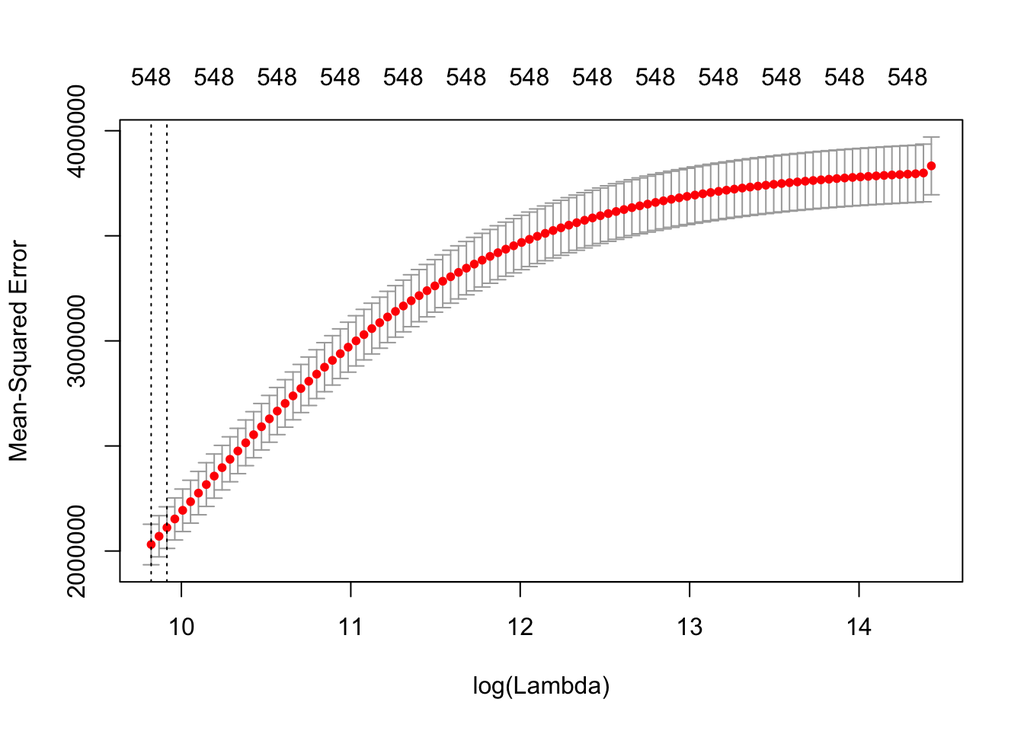

```r
plot(ridge_mod)
```

* When plotted, we see a logarithmic-type of growth for MSE as we increase lambda

1. Lambda min and Lambda 1se

```r
ridge_mod$lambda.min
```

```
## [1] 18428.13
```

```r
ridge_mod$lambda.1se
```

```
## [1] 20224.85
```

- Lambda Min = 18428.13
- Lambda 1se = 20224.85
- lambda.min is the value for lambda at which our Mean-Squared Error is lowest. Although lambda.min is the best for minimizing error on our training data, we use lambda.1se because it does not run the same risk as being over-fit to the training model, and has less bias than lambda.min. All while still being close to the lambda.min (within one standard deviation of it). We prefer this one for our model because it should preform better on test data (and should at least have less bias).

```r
as.matrix(coef(ridge_mod, s = "lambda.min"))
```

```
##                              1
## (Intercept)      -3.716580e+03
## instant           4.035552e-01
## dteday2011-01-01 -2.322856e+02
## dteday2011-01-02 -2.467197e+02
## dteday2011-01-03 -1.935676e+02
## dteday2011-01-04  0.000000e+00
## dteday2011-01-05 -1.785703e+02
## dteday2011-01-06 -1.800694e+02
## dteday2011-01-07 -1.723292e+02
## dteday2011-01-08  0.000000e+00
## dteday2011-01-09 -2.275347e+02
## dteday2011-01-10 -1.911436e+02
## dteday2011-01-11 -1.905490e+02
## dteday2011-01-12  0.000000e+00
## dteday2011-01-13 -1.844364e+02
## dteday2011-01-14 -1.887543e+02
## dteday2011-01-15 -1.992022e+02
## dteday2011-01-16 -2.126398e+02
## dteday2011-01-17  0.000000e+00
## dteday2011-01-18 -2.444357e+02
## dteday2011-01-19 -1.672053e+02
## dteday2011-01-20 -1.424446e+02
## dteday2011-01-21 -1.714282e+02
## dteday2011-01-22 -2.136733e+02
## dteday2011-01-23 -2.139617e+02
## dteday2011-01-24 -1.800702e+02
## dteday2011-01-25 -1.345829e+02
## dteday2011-01-26 -2.386806e+02
## dteday2011-01-27 -2.801433e+02
## dteday2011-01-28  0.000000e+00
## dteday2011-01-29 -2.181712e+02
## dteday2011-01-30 -2.230135e+02
## dteday2011-01-31 -1.684861e+02
## dteday2011-02-01  0.000000e+00
## dteday2011-02-02 -1.749725e+02
## dteday2011-02-03 -1.797006e+02
## dteday2011-02-04 -1.611447e+02
## dteday2011-02-05 -2.187358e+02
## dteday2011-02-06  0.000000e+00
```

[output cut: 716 more lines]

```
## weekdayThursday   1.295668e+01
## weekdayFriday     2.429976e+00
## weekdaySaturday  -4.265006e+00
## workingday        1.163317e+01
## weathersitClear   7.218293e+01
## weathersitLight  -4.568678e+01
## weathersitMedium -2.051479e+02
## weathersitHeavy   0.000000e+00
## temp              3.984474e+02
## atemp             4.597868e+02
## hum              -1.187704e+02
## windspeed        -3.568417e+02
## casual            1.233298e-01
## registered        8.128376e-02
## fahrenheit        2.213619e+02
```

```r
as.matrix(coef(ridge_mod, s = "lambda.1se"))
```

```
##                              1
## (Intercept)      -3.306589e+03
## instant           3.796743e-01
## dteday2011-01-01 -2.188737e+02
## dteday2011-01-02 -2.323449e+02
## dteday2011-01-03 -1.832695e+02
## dteday2011-01-04  0.000000e+00
## dteday2011-01-05 -1.690196e+02
## dteday2011-01-06 -1.702807e+02
## dteday2011-01-07 -1.640431e+02
## dteday2011-01-08  0.000000e+00
## dteday2011-01-09 -2.153870e+02
## dteday2011-01-10 -1.812788e+02
## dteday2011-01-11 -1.810954e+02
## dteday2011-01-12  0.000000e+00
## dteday2011-01-13 -1.750295e+02
## dteday2011-01-14 -1.787086e+02
## dteday2011-01-15 -1.887302e+02
## dteday2011-01-16 -2.006359e+02
## dteday2011-01-17  0.000000e+00
## dteday2011-01-18 -2.307924e+02
## dteday2011-01-19 -1.590145e+02
## dteday2011-01-20 -1.360895e+02
## dteday2011-01-21 -1.630710e+02
## dteday2011-01-22 -2.024645e+02
## dteday2011-01-23 -2.027639e+02
## dteday2011-01-24 -1.711619e+02
## dteday2011-01-25 -1.289747e+02
## dteday2011-01-26 -2.268372e+02
## dteday2011-01-27 -2.629649e+02
## dteday2011-01-28  0.000000e+00
## dteday2011-01-29 -2.059208e+02
## dteday2011-01-30 -2.101981e+02
## dteday2011-01-31 -1.607711e+02
## dteday2011-02-01  0.000000e+00
## dteday2011-02-02 -1.663561e+02
## dteday2011-02-03 -1.702180e+02
## dteday2011-02-04 -1.533792e+02
## dteday2011-02-05 -2.069549e+02
## dteday2011-02-06  0.000000e+00
```

[output cut: 716 more lines]

```
## weekdayThursday   1.206586e+01
## weekdayFriday     2.131849e+00
## weekdaySaturday  -4.044464e+00
## workingday        1.063834e+01
## weathersitClear   6.798168e+01
## weathersitLight  -4.320864e+01
## weathersitMedium -1.919627e+02
## weathersitHeavy   0.000000e+00
## temp              3.788195e+02
## atemp             4.369180e+02
## hum              -1.103187e+02
## windspeed        -3.361577e+02
## casual            1.161072e-01
## registered        7.630663e-02
## fahrenheit        2.104564e+02
```

```r
lasso_mod <- cv.glmnet(cnt ~ .,
                       data = bike_train,
                       alpha = 1)
```

12. Lasso Model’s variables

```r
as.matrix(coef(lasso_mod, s = "lambda.min"))
```

```
##                            1
## (Intercept)      130.6370953
## instant            0.0000000
## dteday2011-01-01   0.0000000
## dteday2011-01-02   0.0000000
## dteday2011-01-03   0.0000000
## dteday2011-01-04   0.0000000
## dteday2011-01-05   0.0000000
## dteday2011-01-06   0.0000000
## dteday2011-01-07   0.0000000
## dteday2011-01-08   0.0000000
## dteday2011-01-09   0.0000000
## dteday2011-01-10   0.0000000
## dteday2011-01-11   0.0000000
## dteday2011-01-12   0.0000000
## dteday2011-01-13   0.0000000
## dteday2011-01-14   0.0000000
## dteday2011-01-15   0.0000000
## dteday2011-01-16   0.0000000
## dteday2011-01-17   0.0000000
## dteday2011-01-18   0.0000000
## dteday2011-01-19   0.0000000
## dteday2011-01-20   0.0000000
## dteday2011-01-21   0.0000000
## dteday2011-01-22   0.0000000
## dteday2011-01-23   0.0000000
## dteday2011-01-24   0.0000000
## dteday2011-01-25   0.0000000
## dteday2011-01-26   0.0000000
## dteday2011-01-27   0.0000000
## dteday2011-01-28   0.0000000
## dteday2011-01-29   0.0000000
## dteday2011-01-30   0.0000000
## dteday2011-01-31   0.0000000
## dteday2011-02-01   0.0000000
## dteday2011-02-02   0.0000000
## dteday2011-02-03   0.0000000
## dteday2011-02-04   0.0000000
## dteday2011-02-05   0.0000000
## dteday2011-02-06   0.0000000
```

[output cut: 716 more lines]

```
## weekdayThursday    0.0000000
## weekdayFriday      0.0000000
## weekdaySaturday    0.0000000
## workingday         0.0000000
## weathersitClear    0.0000000
## weathersitLight    0.0000000
## weathersitMedium   0.0000000
## weathersitHeavy    0.0000000
## temp               0.0000000
## atemp              0.0000000
## hum                0.0000000
## windspeed          0.0000000
## casual             0.9473542
## registered         0.9764899
## fahrenheit         0.0000000
```

```r
as.matrix(coef(lasso_mod, s = "lambda.1se"))
```

```
##                            1
## (Intercept)      130.6370953
## instant            0.0000000
## dteday2011-01-01   0.0000000
## dteday2011-01-02   0.0000000
## dteday2011-01-03   0.0000000
## dteday2011-01-04   0.0000000
## dteday2011-01-05   0.0000000
## dteday2011-01-06   0.0000000
## dteday2011-01-07   0.0000000
## dteday2011-01-08   0.0000000
## dteday2011-01-09   0.0000000
## dteday2011-01-10   0.0000000
## dteday2011-01-11   0.0000000
## dteday2011-01-12   0.0000000
## dteday2011-01-13   0.0000000
## dteday2011-01-14   0.0000000
## dteday2011-01-15   0.0000000
## dteday2011-01-16   0.0000000
## dteday2011-01-17   0.0000000
## dteday2011-01-18   0.0000000
## dteday2011-01-19   0.0000000
## dteday2011-01-20   0.0000000
## dteday2011-01-21   0.0000000
## dteday2011-01-22   0.0000000
## dteday2011-01-23   0.0000000
## dteday2011-01-24   0.0000000
## dteday2011-01-25   0.0000000
## dteday2011-01-26   0.0000000
## dteday2011-01-27   0.0000000
## dteday2011-01-28   0.0000000
## dteday2011-01-29   0.0000000
## dteday2011-01-30   0.0000000
## dteday2011-01-31   0.0000000
## dteday2011-02-01   0.0000000
## dteday2011-02-02   0.0000000
## dteday2011-02-03   0.0000000
## dteday2011-02-04   0.0000000
## dteday2011-02-05   0.0000000
## dteday2011-02-06   0.0000000
```

[output cut: 716 more lines]

```
## weekdayThursday    0.0000000
## weekdayFriday      0.0000000
## weekdaySaturday    0.0000000
## workingday         0.0000000
## weathersitClear    0.0000000
## weathersitLight    0.0000000
## weathersitMedium   0.0000000
## weathersitHeavy    0.0000000
## temp               0.0000000
## atemp              0.0000000
## hum                0.0000000
## windspeed          0.0000000
## casual             0.9473542
## registered         0.9764899
## fahrenheit         0.0000000
```

- Lasso with lambda = lambda.min uses only the variables: casual = 0.9473542 and registered = 0.9764899 (format: variable = coefficient)
- Lasso with lambda = lambda.1se uses only the variables: casual = 0.9473542 and registered = 0.9764899
- So, each version of the model uses 2 variables.
13. Ridge or Lasso? Which to use here?
- Ridge is generally used when your data has a lot of variables, with each of them having a slight significant impact on the outcome of the model, whereas Lasso is generally used when you have a few big-boy variables with a large significant impact on the model’s outcome.
- Here, I would definitely use a ridge model, becasue there are so many variables in this data set, and they all seem to hold a good amount of significance when we plotted them, even as lambda grew / shrunk. Lasso would exclude these important variables from the model, and in this case we should keep them by using Ridge.